# **Problem Statement**

# **Data Preprocessing**

## Converting images to grayscale

[figure not shown]

```python
# Initialize an empty list to store grayscale images.
images_gray = []
# Iterate through each image in the original 'images' array.
for i in range(len(images)):
    # Convert the current image from BGR color space to grayscale.
    img_gray = cv2.cvtColor(images[i], cv2.COLOR_BGR2GRAY)  # Convert to grayscale using OpenCV.
    # Append the grayscale image to the 'images_gray' list.
    images_gray.append(img_gray)

# Select an index for a sample image to display.
n = 0  # Define an index to select a sample image.
# Display the grayscale image at the selected index using cv2_imshow.
cv2_imshow(images_gray[n])
```

This cell converts the color images to grayscale and displays a sample grayscale image. The output shows the grayscale version of the image, confirming the conversion was successful.

### Splitting the dataset

```python
from sklearn.model_selection import train_test_split
# Split the dataset into training, temporary (for validation and test), and target sets.
# test_size=0.4 allocates 40% of the data to the temporary set.
# random_state=42 ensures reproducibility of the split.
# stratify=labels ensures that the split maintains the same class distribution as the original dataset.
X_train, X_temp, y_train, y_temp = train_test_split(np.array(images),labels , test_size=0.4, random_state=42,stratify=labels)
# Split the temporary set into validation and test sets.
# test_size=0.5 allocates 50% of the temporary set (which is 20% of the original data) to the test set.
# random_state=42 ensures reproducibility of the split.
# stratify=y_temp ensures that the split maintains the same class distribution as the temporary set.
X_val, X_test, y_val, y_test = train_test_split(X_temp,y_temp , test_size=0.5, random_state=42,stratify=y_temp)
```

```python
# Print the shape of the training data (features and labels).
# The shape indicates the number of samples and the dimensions of each sample.
print(X_train.shape,y_train.shape)
# Print the shape of the validation data (features and labels).
# This shows the number of samples and their dimensions in the validation set.
print(X_val.shape,y_val.shape)
# Print the shape of the test data (features and labels).
# This shows the number of samples and their dimensions in the test set.
print(X_test.shape,y_test.shape)
```

```
(378, 200, 200, 3) (378, 1)
(126, 200, 200, 3) (126, 1)
(127, 200, 200, 3) (127, 1)
```

The output above shows the shapes of the training, validation, and test sets after splitting the data.

- The training set has 378 images, each with dimensions 200x200 pixels and 3 color channels (RGB), and the corresponding labels.
- The validation set has 126 images and labels with the same dimensions.
- The test set has 127 images and labels with the same dimensions.

The data has been successfully split into the specified proportions (60% train, 20% validation, 20% test).

### Data Normalization

Since the **image pixel values range from 0-255**, our method of normalization here will be **scaling** - we shall **divide all the pixel values by 255 to standardize the images to have values between 0-1.**

```python
X_train_normalized = X_train.astype('float32')/255 # Normalize the training images by dividing by 255 to scale pixel values between 0 and 1.
X_val_normalized = X_val.astype('float32')/255  # Normalize the validation images similarly.
X_test_normalized = X_test.astype('float32')/255   # Normalize the test images similarly.
```

# **Model Building**

## Utility Functions

```python
# Defining a function to compute and return various classification performance metrics.
def model_performance_classification(model, predictors, target):
    """
    Function to compute different metrics to check classification model performance

    model: classifier
    predictors: independent variables
    target: dependent variable
    """

    # Get predictions from the model and reshape to a 1D array.
    # Apply a threshold of 0.5 to convert probabilities to binary class labels (True/False).
    pred = model.predict(predictors).reshape(-1) > 0.5

    # Flatten the target variable to a 1D array to match the shape of predictions.
    target = target.to_numpy().reshape(-1)

    # Calculate various classification metrics:
    acc = accuracy_score(target, pred)  # Accuracy: proportion of correctly classified instances
    recall = recall_score(target, pred, average='weighted')  # Recall: ability of the model to find all the positive samples
    precision = precision_score(target, pred, average='weighted')  # Precision: ability of the model not to label as positive a negative sample
    f1 = f1_score(target, pred, average='weighted')  # F1-score: weighted average of Precision and Recall

    # Create a pandas DataFrame to store and display the calculated metrics.
    df_perf = pd.DataFrame({
        "Accuracy": acc,
        "Recall": recall,
        "Precision": precision,
        "F1 Score": f1,
    }, index=[0])

    # Return the DataFrame containing the performance metrics.
    return df_perf
```

```python
def plot_confusion_matrix(model,predictors,target,ml=False):
    """
    Function to plot the confusion matrix

    model: classifier
    predictors: independent variables
    target: dependent variable
    ml: To specify if the model used is an sklearn ML model or not (True means ML model)
    """

    # Get predictions from the model and reshape to a 1D array.
    # Apply a threshold of 0.5 to convert probabilities to binary class labels (True/False).
    pred = model.predict(predictors).reshape(-1)>0.5

    # Flatten the target variable to a 1D array to match the shape of predictions.
    target = target.to_numpy().reshape(-1)

    # Plotting the Confusion Matrix using tf.math.confusion_matrix
    confusion_matrix = tf.math.confusion_matrix(target,pred)
    f, ax = plt.subplots(figsize=(10, 8))
    sns.heatmap(
        confusion_matrix,
        annot=True, # Annotate cells with the numeric values
        linewidths=.4, # Add lines between cells
        fmt="d", # Format the annotations as integers
        square=True, # Ensure the heatmap is square
        ax=ax # Use the specified axes for plotting
    )
    plt.show() # Display the plot
```

## Model 1: Simple Convolutional Neural Network (CNN)

Let's build a **CNN Model**.

The model has 2 main parts:

1. **The Feature Extraction layers** which are comprised of convolutional and pooling layers.
2. **The Fully Connected classification layers for prediction.**

```python
# Initialize a sequential model, which is a linear stack of layers.
model_1 = Sequential()

# Add the first convolutional layer.
# It has 32 filters, a kernel size of 3x3, uses ReLU activation, and 'same' padding.
# The input shape is specified for the first layer as 200x200 pixels with 3 color channels (RGB).
model_1.add(Conv2D(32, (3, 3), activation='relu', padding="same", input_shape=(200,200,3)))

# Add the first max pooling layer with a pool size of 4x4 and 'same' padding.
# This layer reduces the spatial dimensions of the output from the convolutional layer.
model_1.add(MaxPooling2D((4, 4), padding='same'))

# Add the second convolutional layer with 64 filters, kernel size 3x3, ReLU activation, and 'same' padding.
model_1.add(Conv2D(64, (3, 3), activation='relu', padding="same"))

# Add the second max pooling layer with a pool size of 2x2 and 'same' padding.
model_1.add(MaxPooling2D((2,2), padding='same'))

# Add the third convolutional layer with 128 filters, kernel size 3x3, ReLU activation, and 'same' padding.
model_1.add(Conv2D(128, (3,3), activation='relu', padding="same"))

# Flatten the output of the convolutional layers.
# This converts the 3D output into a 1D vector to be fed into the dense layers.
model_1.add(Flatten())

# Add a dense layer with 4 neurons and ReLU activation.
model_1.add(Dense(4, activation='relu'))

# Add the output dense layer with a single neuron and sigmoid activation.
# Sigmoid activation is used for binary classification to output a probability between 0 and 1.
model_1.add(Dense(1, activation='sigmoid'))

# Define the optimizer for the model.
# Using the Adam optimizer with a learning rate of 0.001.
opt = Adam(learning_rate=0.001)

# Compile the model.
# Specify the optimizer, the loss function (binary crossentropy for binary classification),
# and the metrics to monitor during training (accuracy and recall).
model_1.compile(optimizer=opt, loss='binary_crossentropy', metrics=["accuracy","recall"])

# Display the model summary.
# This shows the layers of the model, their output shapes, and the number of parameters in each layer.
model_1.summary()
```

```
Model: "sequential_4"
```

```
┏━━━━━━━━━━━━━━━━━━━━━━━━━━━━━━━━━┳━━━━━━━━━━━━━━━━━━━━━━━━┳━━━━━━━━━━━━━━━┓
┃ Layer (type)                    ┃ Output Shape           ┃       Param # ┃
┡━━━━━━━━━━━━━━━━━━━━━━━━━━━━━━━━━╇━━━━━━━━━━━━━━━━━━━━━━━━╇━━━━━━━━━━━━━━━┩
│ conv2d_3 (Conv2D)               │ (None, 200, 200, 32)   │           896 │
├─────────────────────────────────┼────────────────────────┼───────────────┤
│ max_pooling2d_2 (MaxPooling2D)  │ (None, 50, 50, 32)     │             0 │
├─────────────────────────────────┼────────────────────────┼───────────────┤
│ conv2d_4 (Conv2D)               │ (None, 50, 50, 64)     │        18,496 │
├─────────────────────────────────┼────────────────────────┼───────────────┤
│ max_pooling2d_3 (MaxPooling2D)  │ (None, 25, 25, 64)     │             0 │
├─────────────────────────────────┼────────────────────────┼───────────────┤
│ conv2d_5 (Conv2D)               │ (None, 25, 25, 128)    │        73,856 │
├─────────────────────────────────┼────────────────────────┼───────────────┤
│ flatten_4 (Flatten)             │ (None, 80000)          │             0 │
├─────────────────────────────────┼────────────────────────┼───────────────┤
│ dense_9 (Dense)                 │ (None, 4)              │       320,004 │
├─────────────────────────────────┼────────────────────────┼───────────────┤
│ dense_10 (Dense)                │ (None, 1)              │             5 │
└─────────────────────────────────┴────────────────────────┴───────────────┘
```

```
 Total params: 413,257 (1.58 MB)
```

```
 Trainable params: 413,257 (1.58 MB)
```

```
 Non-trainable params: 0 (0.00 B)
```

The output of this cell is the summary of the first CNN model (`model_1`). It shows the different layers of the model, their output shapes, and the number of parameters in each layer. This helps in understanding the architecture of the model, including the convolutional and pooling layers for feature extraction, and the flatten and dense layers for classification. The total number of trainable parameters is also shown.

```python
# Train the model.
history_1 = model_1.fit(
            X_train_normalized, y_train,
            epochs=10, # Define the number of training epochs.
            validation_data=(X_val_normalized,y_val), # Provide validation data for monitoring performance during training.
            shuffle=True, # Shuffle the training data before each epoch.
            batch_size=32, # Define the batch size for training.
            verbose=2 # Set verbose to 2 to see training progress per epoch.
)
```

```
12/12 - 7s - 564ms/step - accuracy: 0.4894 - loss: 0.6976 - recall: 0.1452 - val_accuracy: 0.5159 - val_loss: 0.6865 - val_recall: 0.0161
12/12 - 0s - 38ms/step - accuracy: 0.6296 - loss: 0.6140 - recall: 0.3226 - val_accuracy: 0.7063 - val_loss: 0.5073 - val_recall: 0.4032
12/12 - 0s - 34ms/step - accuracy: 0.9259 - loss: 0.2446 - recall: 0.8871 - val_accuracy: 0.9841 - val_loss: 0.0589 - val_recall: 0.9677
12/12 - 0s - 33ms/step - accuracy: 0.9921 - loss: 0.0214 - recall: 0.9892 - val_accuracy: 0.9286 - val_loss: 0.2050 - val_recall: 1.0000
12/12 - 0s - 33ms/step - accuracy: 0.9392 - loss: 0.2262 - recall: 0.9355 - val_accuracy: 0.9365 - val_loss: 0.3062 - val_recall: 0.8710
12/12 - 0s - 33ms/step - accuracy: 0.9762 - loss: 0.1134 - recall: 0.9731 - val_accuracy: 0.9444 - val_loss: 0.1683 - val_recall: 0.8871
12/12 - 0s - 33ms/step - accuracy: 0.9841 - loss: 0.0643 - recall: 0.9677 - val_accuracy: 1.0000 - val_loss: 0.0318 - val_recall: 1.0000
12/12 - 0s - 33ms/step - accuracy: 0.9974 - loss: 0.0162 - recall: 0.9946 - val_accuracy: 1.0000 - val_loss: 0.0045 - val_recall: 1.0000
12/12 - 0s - 34ms/step - accuracy: 1.0000 - loss: 0.0025 - recall: 1.0000 - val_accuracy: 1.0000 - val_loss: 0.0011 - val_recall: 1.0000
12/12 - 0s - 32ms/step - accuracy: 1.0000 - loss: 3.6070e-04 - recall: 1.0000 - val_accuracy: 0.9921 - val_loss: 0.0151 - val_recall: 0.9839
```

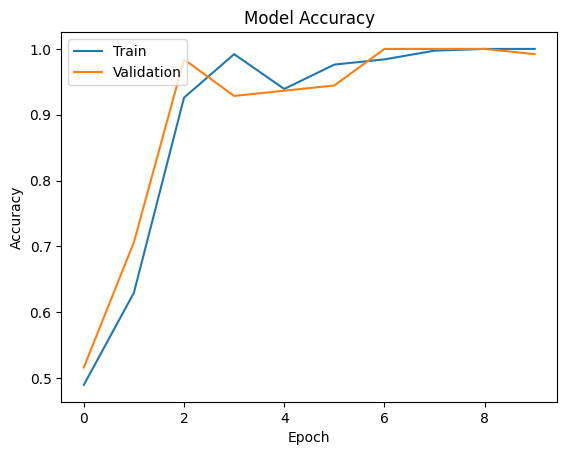

```python
# Plot the training accuracy over epochs from the history object.
plt.plot(history_1.history['accuracy'])
# Plot the validation accuracy over epochs from the history object.
plt.plot(history_1.history['val_accuracy'])

# Set the title of the plot.
plt.title('Model Accuracy')

# Set the label for the y-axis.
plt.ylabel('Accuracy')

# Set the label for the x-axis.
plt.xlabel('Epoch')

# Add a legend to the plot to identify the training and validation lines.
plt.legend(['Train', 'Validation'], loc='upper left')

# Display the generated plot.
plt.show()
```

```python
# Calculate performance metrics for the training set using the model_performance_classification function.
model_1_train_perf = model_performance_classification(model_1, X_train_normalized,y_train)


# Print the training performance metrics.
print("Train performance metrics")
print(model_1_train_perf)
```

```
12/12 ━━━━━━━━━━━━━━━━━━━━ 0s 13ms/step
Train performance metrics
   Accuracy  Recall  Precision  F1 Score
0       1.0     1.0        1.0       1.0
```

This cell displays the training performance metrics (Accuracy, Recall, Precision, and F1 Score) for Model 1. The output shows very high scores across all metrics (close to 1.0), indicating that Model 1 performs exceptionally well on the training data.

```python
# Plot the confusion matrix for the training data using the defined function.
plot_confusion_matrix(model_1,X_train_normalized,y_train)
```

```
12/12 ━━━━━━━━━━━━━━━━━━━━ 0s 19ms/step
```

```python
# Calculate performance metrics for the validation set using the model_performance_classification function.
model_1_valid_perf = model_performance_classification(model_1, X_val_normalized,y_val)

# Print the validation performance metrics.
print("Validation performance metrics")
print(model_1_valid_perf)
```

[output not shown]

This cell displays the validation performance metrics (Accuracy, Recall, Precision, and F1 Score) for Model 1. The output shows high scores across all metrics, indicating that Model 1 generalizes well to unseen data, although there is a slight drop compared to the training performance.

```
4/4 ━━━━━━━━━━━━━━━━━━━━ 0s 14ms/step
```

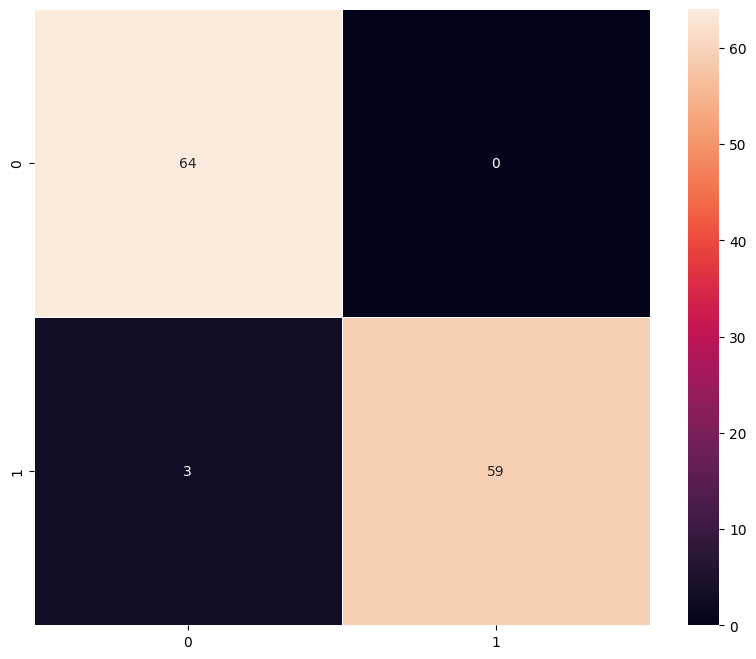

```python
# Plot the confusion matrix for the validation data using the defined function.
plot_confusion_matrix(model_1,X_val_normalized,y_val)
```

This cell displays the confusion matrix for Model 1 on the validation data. Similar to the training confusion matrix, it shows the counts of true positive, true negative, false positive, and false negative predictions on the validation set. The high number of true positives and true negatives, and low numbers of false positives and false negatives, further indicate that the model is performing well on unseen data.

### Vizualizing the predictions

```python
# For index 2
plt.figure(figsize=(2,2))
plt.imshow(X_val[12])
plt.show()
# Get the prediction for the image at index 2
prediction = model_1.predict(X_val_normalized[2].reshape(1,200,200,3))
# Convert the prediction (probability) to a class label (0 or 1) based on a threshold of 0.5.
predicted_label = prediction[0][0]>0.5  # Extract the predicted class label
print('Predicted Label:', 1 if predicted_label else 0)
# Get the true label for the image at index 12 from the validation set.
true_label = y_val.iloc[12]
print('True Label:', true_label)

# For index 33
plt.figure(figsize=(2,2))
plt.imshow(X_val[33])
plt.show()
# Get the prediction for the image at index 2
prediction = model_1.predict(X_val_normalized[2].reshape(1,200,200,3))
# Convert the prediction (probability) to a class label (0 or 1) based on a threshold of 0.5.
predicted_label = prediction[0][0]>0.5  # Extract the predicted class label
print('Predicted Label:', 1 if predicted_label else 0)
# Get the true label for the image at index 33 from the validation set.
true_label = y_val.iloc[33]
print('True Label:', true_label)
```

```
1/1 ━━━━━━━━━━━━━━━━━━━━ 1s 547ms/step
Predicted Label: 1
True Label: Label    1
Name: 244, dtype: int64
```

```
1/1 ━━━━━━━━━━━━━━━━━━━━ 0s 30ms/step
Predicted Label: 1
True Label: Label    0
Name: 329, dtype: int64
```

This cell visualizes two sample images from the validation set and displays the model's prediction along with the true label for each. The output shows that for index 12, the model correctly predicted "With Helmet" (Label 1), and for index 33, the model incorrectly predicted "With Helmet" (Label 1) when the true label was "Without Helmet" (Label 0). This provides a visual check of the model's performance on individual examples.

## Model 2: (VGG-16 (Base))

- We will be loading a pre-built architecture - **VGG16**, which was trained on the ImageNet dataset and is the runner-up in the ImageNet competition in 2014.
- For training VGG16, we will directly use the convolutional and pooling layers and freeze their weights i.e. no training will be done on them. For classification, we will add a Flatten and a single dense layer.

```python
# Load the VGG16 model with pre-trained weights from the ImageNet dataset.
# weights='imagenet' specifies using weights pre-trained on ImageNet.
# include_top=False removes the classifier layers at the top of the network,
# allowing us to add our own classification layers for the specific task.
# input_shape=(200,200,3) defines the expected input image shape (height, width, color channels).
vgg_model = VGG16(weights='imagenet',include_top=False,input_shape=(200,200,3))
# Display the summary of the VGG16 model architecture.
# This shows the layers, output shapes, and the number of parameters in the loaded model.
vgg_model.summary()
```

```
Model: "vgg16"
```

```
┏━━━━━━━━━━━━━━━━━━━━━━━━━━━━━━━━━┳━━━━━━━━━━━━━━━━━━━━━━━━┳━━━━━━━━━━━━━━━┓
┃ Layer (type)                    ┃ Output Shape           ┃       Param # ┃
┡━━━━━━━━━━━━━━━━━━━━━━━━━━━━━━━━━╇━━━━━━━━━━━━━━━━━━━━━━━━╇━━━━━━━━━━━━━━━┩
│ input_layer_1 (InputLayer)      │ (None, 200, 200, 3)    │             0 │
├─────────────────────────────────┼────────────────────────┼───────────────┤
│ block1_conv1 (Conv2D)           │ (None, 200, 200, 64)   │         1,792 │
├─────────────────────────────────┼────────────────────────┼───────────────┤
│ block1_conv2 (Conv2D)           │ (None, 200, 200, 64)   │        36,928 │
├─────────────────────────────────┼────────────────────────┼───────────────┤
│ block1_pool (MaxPooling2D)      │ (None, 100, 100, 64)   │             0 │
├─────────────────────────────────┼────────────────────────┼───────────────┤
│ block2_conv1 (Conv2D)           │ (None, 100, 100, 128)  │        73,856 │
├─────────────────────────────────┼────────────────────────┼───────────────┤
│ block2_conv2 (Conv2D)           │ (None, 100, 100, 128)  │       147,584 │
├─────────────────────────────────┼────────────────────────┼───────────────┤
│ block2_pool (MaxPooling2D)      │ (None, 50, 50, 128)    │             0 │
├─────────────────────────────────┼────────────────────────┼───────────────┤
│ block3_conv1 (Conv2D)           │ (None, 50, 50, 256)    │       295,168 │
├─────────────────────────────────┼────────────────────────┼───────────────┤
│ block3_conv2 (Conv2D)           │ (None, 50, 50, 256)    │       590,080 │
├─────────────────────────────────┼────────────────────────┼───────────────┤
│ block3_conv3 (Conv2D)           │ (None, 50, 50, 256)    │       590,080 │
├─────────────────────────────────┼────────────────────────┼───────────────┤
│ block3_pool (MaxPooling2D)      │ (None, 25, 25, 256)    │             0 │
├─────────────────────────────────┼────────────────────────┼───────────────┤
│ block4_conv1 (Conv2D)           │ (None, 25, 25, 512)    │     1,180,160 │
├─────────────────────────────────┼────────────────────────┼───────────────┤
│ block4_conv2 (Conv2D)           │ (None, 25, 25, 512)    │     2,359,808 │
├─────────────────────────────────┼────────────────────────┼───────────────┤
│ block4_conv3 (Conv2D)           │ (None, 25, 25, 512)    │     2,359,808 │
├─────────────────────────────────┼────────────────────────┼───────────────┤
│ block4_pool (MaxPooling2D)      │ (None, 12, 12, 512)    │             0 │
├─────────────────────────────────┼────────────────────────┼───────────────┤
│ block5_conv1 (Conv2D)           │ (None, 12, 12, 512)    │     2,359,808 │
├─────────────────────────────────┼────────────────────────┼───────────────┤
│ block5_conv2 (Conv2D)           │ (None, 12, 12, 512)    │     2,359,808 │
├─────────────────────────────────┼────────────────────────┼───────────────┤
│ block5_conv3 (Conv2D)           │ (None, 12, 12, 512)    │     2,359,808 │
├─────────────────────────────────┼────────────────────────┼───────────────┤
│ block5_pool (MaxPooling2D)      │ (None, 6, 6, 512)      │             0 │
└─────────────────────────────────┴────────────────────────┴───────────────┘
```

```
 Total params: 14,714,688 (56.13 MB)
```

```
 Trainable params: 14,714,688 (56.13 MB)
```

```
 Non-trainable params: 0 (0.00 B)
```

The output of this cell shows the summary of the VGG16 base model. It lists the layers of the pre-trained VGG16 network, their output shapes, and the number of parameters. This summary confirms that the VGG16 model is loaded with pre-trained weights and that the `include_top` parameter is set to `False`, removing the classification layers at the top.

```python
# Iterate through each layer in the VGG model.
for layer in vgg_model.layers:
    # Set the 'trainable' attribute of the layer to False.
    # This freezes the weights of the layer, preventing them from being updated during training.
    layer.trainable = False
```

```python
# Initialize a Sequential model, which is a linear stack of layers.
model_2 = Sequential()

# Add the pre-trained VGG16 base model as the first layer.
# This leverages the feature extraction capabilities learned from the ImageNet dataset.
model_2.add(vgg_model)

# Flatten the output of the VGG16 base model.
# The convolutional layers of VGG16 produce a 3D output (height, width, filters).
# The Flatten layer converts this 3D output into a 1D vector, which is required for the subsequent dense layers.
model_2.add(Flatten())

# Add a dense output layer for binary classification.
# This layer has a single neuron because it's a binary classification problem (With Helmet vs Without Helmet).
# The sigmoid activation function is used to output a probability between 0 and 1, representing the likelihood of the positive class (With Helmet).
model_2.add(Dense(1, activation='sigmoid'))
```

```python
# Define the Adam optimizer with a specified learning rate.
# The Adam optimizer is an efficient stochastic optimization method that
# is widely used for training deep neural networks.
opt=Adam(learning_rate=0.001)

# Compile the model with the specified optimizer, loss function, and metrics.
# optimizer: The optimization algorithm to use (e.g., Adam).
# loss: The loss function to minimize during training (BinaryCrossentropy for binary classification).
# metrics: The metrics to evaluate the model during training and testing (e.g., accuracy).
model_2.compile(optimizer=opt, loss=keras.losses.BinaryCrossentropy(), metrics=["accuracy"])
```

```python
# Generating the summary of the model to see the architecture and number of parameters.
model_2.summary()
```

```
Model: "sequential_1"
```

```
┏━━━━━━━━━━━━━━━━━━━━━━━━━━━━━━━━━┳━━━━━━━━━━━━━━━━━━━━━━━━┳━━━━━━━━━━━━━━━┓
┃ Layer (type)                    ┃ Output Shape           ┃       Param # ┃
┡━━━━━━━━━━━━━━━━━━━━━━━━━━━━━━━━━╇━━━━━━━━━━━━━━━━━━━━━━━━╇━━━━━━━━━━━━━━━┩
│ vgg16 (Functional)              │ (None, 6, 6, 512)      │    14,714,688 │
├─────────────────────────────────┼────────────────────────┼───────────────┤
│ flatten_1 (Flatten)             │ (None, 18432)          │             0 │
├─────────────────────────────────┼────────────────────────┼───────────────┤
│ dense_2 (Dense)                 │ (None, 1)              │        18,433 │
└─────────────────────────────────┴────────────────────────┴───────────────┘
```

```
 Total params: 14,733,121 (56.20 MB)
```

```
 Trainable params: 18,433 (72.00 KB)
```

```
 Non-trainable params: 14,714,688 (56.13 MB)
```

The output of this cell shows the summary of Model 2. This model consists of the pre-trained VGG16 base with its layers frozen (non-trainable), followed by a Flatten layer and a dense output layer with a sigmoid activation function for binary classification. The summary shows the number of parameters for each layer, highlighting that the majority of parameters belong to the non-trainable VGG16 base, while only the parameters in the dense output layer are trainable.

```python
# Initialize ImageDataGenerator for data augmentation (though not used for augmentation in this specific training step).
# This generator will be used to feed data to the model during training.
train_datagen = ImageDataGenerator()
```

```python
# Initialize an ImageDataGenerator for use with the model.
train_datagen = ImageDataGenerator()
# Define the number of training epochs.
epochs = 10
# Define the batch size for training.
batch_size = 32

# Train Model 2 using the fit method.
history_2 = model_2.fit(train_datagen.flow(X_train_normalized,y_train,
                                      batch_size=batch_size, # Specify the batch size for the data generator.
                                      seed=42, # Set a seed for reproducibility.
                                      shuffle=False), # Do not shuffle the data for this model's training.
                    epochs=epochs, # Specify the number of epochs to train for.
                    steps_per_epoch=X_train_normalized.shape[0] // batch_size, # Define the number of steps per epoch.
                    validation_data=(X_val_normalized,y_val), # Provide validation data to evaluate the model during training.
                    verbose=1) # Set verbose to 1 to see training progress.
```

```
11/11 ━━━━━━━━━━━━━━━━━━━━ 44s 3s/step - accuracy: 0.7982 - loss: 0.4551 - val_accuracy: 1.0000 - val_loss: 0.0367
11/11 ━━━━━━━━━━━━━━━━━━━━ 1s 71ms/step - accuracy: 1.0000 - loss: 0.0291 - val_accuracy: 1.0000 - val_loss: 0.0317
11/11 ━━━━━━━━━━━━━━━━━━━━ 2s 229ms/step - accuracy: 1.0000 - loss: 0.0161 - val_accuracy: 1.0000 - val_loss: 0.0101
11/11 ━━━━━━━━━━━━━━━━━━━━ 1s 67ms/step - accuracy: 1.0000 - loss: 0.0045 - val_accuracy: 1.0000 - val_loss: 0.0097
11/11 ━━━━━━━━━━━━━━━━━━━━ 2s 230ms/step - accuracy: 1.0000 - loss: 0.0042 - val_accuracy: 1.0000 - val_loss: 0.0079
11/11 ━━━━━━━━━━━━━━━━━━━━ 1s 69ms/step - accuracy: 1.0000 - loss: 0.0097 - val_accuracy: 1.0000 - val_loss: 0.0077
11/11 ━━━━━━━━━━━━━━━━━━━━ 2s 231ms/step - accuracy: 1.0000 - loss: 0.0037 - val_accuracy: 1.0000 - val_loss: 0.0060
11/11 ━━━━━━━━━━━━━━━━━━━━ 1s 69ms/step - accuracy: 1.0000 - loss: 0.0017 - val_accuracy: 1.0000 - val_loss: 0.0059
11/11 ━━━━━━━━━━━━━━━━━━━━ 3s 236ms/step - accuracy: 1.0000 - loss: 0.0022 - val_accuracy: 1.0000 - val_loss: 0.0054
11/11 ━━━━━━━━━━━━━━━━━━━━ 1s 72ms/step - accuracy: 1.0000 - loss: 0.0016 - val_accuracy: 1.0000 - val_loss: 0.0054
```

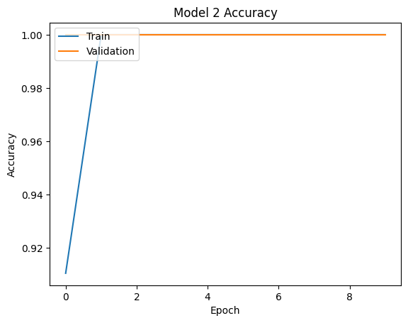

```python
# Plot the training accuracy over epochs from the history object.
plt.plot(history_2.history['accuracy'])
# Plot the validation accuracy over epochs from the history object.
plt.plot(history_2.history['val_accuracy'])
# Set the title of the plot to indicate it's for Model 2 Accuracy.
plt.title('Model 2 Accuracy')
# Set the label for the y-axis to 'Accuracy'.
plt.ylabel('Accuracy')
# Set the label for the x-axis to 'Epoch'.
plt.xlabel('Epoch')
# Add a legend to the plot to identify the training and validation lines.
plt.legend(['Train', 'Validation'], loc='upper left')
# Display the generated plot.
plt.show()
```

The output of this cell shows the training progress of Model 2 over 10 epochs. It displays the accuracy and loss for both the training and validation data in each epoch. The output shows that the accuracy quickly reaches 1.0 for both training and validation data, indicating that Model 2 is performing very well.

The plot above shows the training and validation accuracy for Model 2 across 10 epochs. The training accuracy quickly reaches 1.0, and the validation accuracy also reaches 1.0 and stays there for most of the epochs, suggesting that Model 2 is performing very well on both the training and validation data.

```python
# Calculate performance metrics for the training set using the model_performance_classification function.
model_2_train_perf = model_performance_classification(model_2,X_train_normalized,y_train)


# Print the training performance metrics.
print("Train performance metrics")
print(model_2_train_perf)
```

```
12/12 ━━━━━━━━━━━━━━━━━━━━ 4s 275ms/step
Train performance metrics
   Accuracy  Recall  Precision  F1 Score
0       1.0     1.0        1.0       1.0
```

This cell displays the training performance metrics (Accuracy, Recall, Precision, and F1 Score) for Model 2. The output shows perfect scores (1.0) across all metrics, indicating that Model 2 performs exceptionally well on the training data.

```python
# Plot the confusion matrix for the training data using the defined function.
plot_confusion_matrix(model_2,X_train_normalized,y_train)
```

```
12/12 ━━━━━━━━━━━━━━━━━━━━ 2s 157ms/step
```

```python
# Calculate performance metrics for the validation set using the model_performance_classification function.
model_2_valid_perf = model_performance_classification(model_2, X_val_normalized,y_val)

# Print the validation performance metrics.
print("Validation performance metrics")
print(model_2_valid_perf)
```

```
4/4 ━━━━━━━━━━━━━━━━━━━━ 1s 338ms/step
Validation performance metrics
   Accuracy  Recall  Precision  F1 Score
0       1.0     1.0        1.0       1.0
```

This cell displays the validation performance metrics (Accuracy, Recall, Precision, and F1 Score) for Model 2. The output shows perfect scores (1.0) across all metrics, indicating that Model 2 generalizes exceptionally well to unseen data.

```python
# Plot the confusion matrix for the validation data using the defined function.
plot_confusion_matrix(model_2,X_val_normalized,y_val)
```

```
4/4 ━━━━━━━━━━━━━━━━━━━━ 1s 161ms/step
```

### Visualizing the prediction:

```python
# For index 2
plt.figure(figsize=(2,2))
plt.imshow(X_val[12])
plt.show()
# Get the prediction for the image at index 2
prediction = model_1.predict(X_val_normalized[2].reshape(1,200,200,3))
# Convert the prediction (probability) to a class label (0 or 1) based on a threshold of 0.5.
predicted_label = prediction[0][0]>0.5  # Extract the predicted class label
print('Predicted Label:', 1 if predicted_label else 0)
# Get the true label for the image at index 12 from the validation set.
true_label = y_val.iloc[12]
print('True Label:', true_label)

# For index 33
plt.figure(figsize=(2,2))
plt.imshow(X_val[33])
plt.show()
# Get the prediction for the image at index 2
prediction = model_1.predict(X_val_normalized[2].reshape(1,200,200,3))
# Convert the prediction (probability) to a class label (0 or 1) based on a threshold of 0.5.
predicted_label = prediction[0][0]>0.5  # Extract the predicted class label
print('Predicted Label:', 1 if predicted_label else 0)
# Get the true label for the image at index 33 from the validation set.
true_label = y_val.iloc[33]
print('True Label:', true_label)
```

```
1/1 ━━━━━━━━━━━━━━━━━━━━ 0s 32ms/step
Predicted Label: 1
True Label: Label    1
Name: 244, dtype: int64
```

```
1/1 ━━━━━━━━━━━━━━━━━━━━ 0s 32ms/step
Predicted Label: 1
True Label: Label    0
Name: 329, dtype: int64
```

This cell visualizes two sample images from the validation set and displays the model's prediction along with the true label for each. The output shows that for index 12, the model correctly predicted "With Helmet" (Label 1), and for index 33, the model incorrectly predicted "With Helmet" (Label 1) when the true label was "Without Helmet" (Label 0). This provides a visual check of the model's performance on individual examples.

## Model 3: (VGG-16 (Base + FFNN))

- We will directly use the convolutional and pooling layers and freeze their weights i.e. no training will be done on them. For classification, we will add a Flatten layer and a Feed Forward Neural Network.

```python
model_3 = Sequential()

# Adding the convolutional part of the VGG16 model from above
model_3.add(vgg_model)

# Flattening the output of the VGG16 model because it is from a convolutional layer
model_3.add(Flatten())

#Adding the Feed Forward neural network
# First dense layer in the FFNN with 128 neurons and ReLU activation.
model_3.add(Dense(128,activation='relu'))
# Dropout layer to prevent overfitting, dropping 50% of the neurons.
model_3.add(Dropout(rate=0.5))
# Second dense layer in the FFNN with 64 neurons and ReLU activation.
model_3.add(Dense(64,activation='relu'))

# Adding a dense output layer with a single neuron and sigmoid activation for binary classification.
model_3.add(Dense(1, activation='sigmoid'))
```

```python
# Define the Adam optimizer with a specified learning rate.
# The Adam optimizer is an efficient stochastic optimization method that
# is widely used for training deep neural networks.
opt = Adam(learning_rate=0.001)
```

```python
# Compile the model with the specified optimizer, loss function, and metrics.
# optimizer: The optimization algorithm to use (e.g., Adam).
# loss: The loss function to minimize during training (BinaryCrossentropy for binary classification).
# metrics: The metrics to evaluate the model during training and testing (e.g., accuracy).
model_3.compile(optimizer=opt,loss=keras.losses.BinaryCrossentropy(), metrics=["accuracy"])
```

```python
# Generating the summary of the model
model_3.summary()
```

```
Model: "sequential_2"
```

```
┏━━━━━━━━━━━━━━━━━━━━━━━━━━━━━━━━━┳━━━━━━━━━━━━━━━━━━━━━━━━┳━━━━━━━━━━━━━━━┓
┃ Layer (type)                    ┃ Output Shape           ┃       Param # ┃
┡━━━━━━━━━━━━━━━━━━━━━━━━━━━━━━━━━╇━━━━━━━━━━━━━━━━━━━━━━━━╇━━━━━━━━━━━━━━━┩
│ vgg16 (Functional)              │ (None, 6, 6, 512)      │    14,714,688 │
├─────────────────────────────────┼────────────────────────┼───────────────┤
│ flatten_2 (Flatten)             │ (None, 18432)          │             0 │
├─────────────────────────────────┼────────────────────────┼───────────────┤
│ dense_3 (Dense)                 │ (None, 128)            │     2,359,424 │
├─────────────────────────────────┼────────────────────────┼───────────────┤
│ dropout (Dropout)               │ (None, 128)            │             0 │
├─────────────────────────────────┼────────────────────────┼───────────────┤
│ dense_4 (Dense)                 │ (None, 64)             │         8,256 │
├─────────────────────────────────┼────────────────────────┼───────────────┤
│ dense_5 (Dense)                 │ (None, 1)              │            65 │
└─────────────────────────────────┴────────────────────────┴───────────────┘
```

```
 Total params: 21,817,925 (83.23 MB)
```

```
 Trainable params: 2,367,745 (9.03 MB)
```

```
 Non-trainable params: 14,714,688 (56.13 MB)
```

```
 Optimizer params: 4,735,492 (18.06 MB)
```

The output of this cell shows the summary of Model 3. This model consists of the pre-trained VGG16 base with its layers frozen (non-trainable), followed by a Flatten layer and a Feed Forward Neural Network with Dropout, and finally a dense output layer with a sigmoid activation function for binary classification. The summary shows the number of parameters for each layer, highlighting that the majority of parameters belong to the non-trainable VGG16 base, while a significant number of trainable parameters are in the Feed Forward and output layers.

```python
history_3 = model_3.fit(train_datagen.flow(X_train_normalized,y_train,
                                       batch_size=32, # Define the batch size for training.
                                       seed=42,
                                       shuffle=False),
                    epochs=10, # Define the number of training epochs.
                    steps_per_epoch=X_train_normalized.shape[0] // batch_size,
                    validation_data=(X_val_normalized,y_val),
                    verbose=1)
```

```
11/11 ━━━━━━━━━━━━━━━━━━━━ 11s 676ms/step - accuracy: 0.8234 - loss: 0.3091 - val_accuracy: 1.0000 - val_loss: 0.0022
11/11 ━━━━━━━━━━━━━━━━━━━━ 1s 68ms/step - accuracy: 1.0000 - loss: 0.0020 - val_accuracy: 1.0000 - val_loss: 0.0014
11/11 ━━━━━━━━━━━━━━━━━━━━ 2s 230ms/step - accuracy: 0.9885 - loss: 0.0211 - val_accuracy: 1.0000 - val_loss: 8.1256e-04
11/11 ━━━━━━━━━━━━━━━━━━━━ 1s 69ms/step - accuracy: 1.0000 - loss: 0.0217 - val_accuracy: 1.0000 - val_loss: 3.8178e-04
11/11 ━━━━━━━━━━━━━━━━━━━━ 3s 233ms/step - accuracy: 1.0000 - loss: 0.0011 - val_accuracy: 1.0000 - val_loss: 1.8653e-05
11/11 ━━━━━━━━━━━━━━━━━━━━ 1s 70ms/step - accuracy: 1.0000 - loss: 1.9194e-05 - val_accuracy: 1.0000 - val_loss: 1.6329e-05
11/11 ━━━━━━━━━━━━━━━━━━━━ 3s 236ms/step - accuracy: 1.0000 - loss: 1.2418e-04 - val_accuracy: 1.0000 - val_loss: 8.2550e-06
11/11 ━━━━━━━━━━━━━━━━━━━━ 1s 72ms/step - accuracy: 1.0000 - loss: 1.6469e-06 - val_accuracy: 1.0000 - val_loss: 8.0235e-06
11/11 ━━━━━━━━━━━━━━━━━━━━ 3s 244ms/step - accuracy: 1.0000 - loss: 7.5011e-04 - val_accuracy: 1.0000 - val_loss: 1.6371e-05
11/11 ━━━━━━━━━━━━━━━━━━━━ 1s 70ms/step - accuracy: 1.0000 - loss: 3.9365e-06 - val_accuracy: 1.0000 - val_loss: 1.7824e-05
```

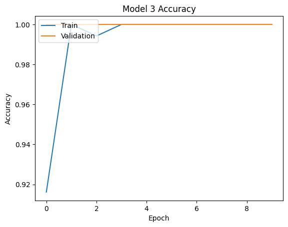

```python
# Plot the training accuracy over epochs.
plt.plot(history_3.history['accuracy'])
# Plot the validation accuracy over epochs.
plt.plot(history_3.history['val_accuracy'])
# Set the title of the plot.
plt.title('Model 3 Accuracy')
# Set the label for the y-axis.
plt.ylabel('Accuracy')
# Set the label for the x-axis.
plt.xlabel('Epoch')
# Add a legend to distinguish between training and validation accuracy.
plt.legend(['Train', 'Validation'], loc='upper left')
# Display the plot.
plt.show()
```

The output of this cell shows the training progress of Model 3 over 10 epochs. Similar to Model 2, the output shows that the accuracy quickly reaches 1.0 for both training and validation data, indicating that Model 3 is performing exceptionally well.

The plot above shows the training and validation accuracy for Model 3 across 10 epochs. Both the training and validation accuracy reach 1.0 very quickly and stay there, indicating that Model 3 is performing exceptionally well on both datasets.

```python
# Calculate performance metrics for the training set using the model_performance_classification function.
model_3_train_perf = model_performance_classification(model_3, X_train_normalized,y_train)

# Print the training performance metrics.
print("Train performance metrics")
print(model_3_train_perf)
```

```
12/12 ━━━━━━━━━━━━━━━━━━━━ 3s 219ms/step
Train performance metrics
   Accuracy  Recall  Precision  F1 Score
0       1.0     1.0        1.0       1.0
```

This cell displays the training performance metrics (Accuracy, Recall, Precision, and F1 Score) for Model 3. The output shows perfect scores (1.0) across all metrics, indicating that Model 3 performs exceptionally well on the training data.

```python
# Plot the confusion matrix for the training data using the defined function.
plot_confusion_matrix(model_3,X_train_normalized,y_train)
```

```
12/12 ━━━━━━━━━━━━━━━━━━━━ 2s 168ms/step
```

```python
# Calculate performance metrics for the validation set using the model_performance_classification function.
model_3_valid_perf = model_performance_classification(model_3, X_val_normalized,y_val)

# Print the validation performance metrics.
print("Validation performance metrics")
print(model_3_valid_perf)
```

```
4/4 ━━━━━━━━━━━━━━━━━━━━ 1s 310ms/step
Validation performance metrics
   Accuracy  Recall  Precision  F1 Score
0       1.0     1.0        1.0       1.0
```

This cell displays the validation performance metrics (Accuracy, Recall, Precision, and F1 Score) for Model 3. The output shows perfect scores (1.0) across all metrics, indicating that Model 3 generalizes exceptionally well to unseen data.

```python
# Plot the confusion matrix for the validation data using the defined function.
plot_confusion_matrix(model_3,X_val_normalized,y_val)
```

```
4/4 ━━━━━━━━━━━━━━━━━━━━ 1s 167ms/step
```

#### Visualizing the predictions

```python
# Visualize a sample prediction for the validation set.
plt.figure(figsize=(2,2))
# Display the image at index 12 from the validation set.
plt.imshow(X_val[12])
plt.show()
# Get the prediction for the image at index 12 using Model 2.
prediction = model_2.predict(X_val_normalized[12].reshape(1,200,200,3))
# Convert the prediction (probability) to a class label (0 or 1) based on a threshold of 0.5.
predicted_label = prediction[0][0]>0.5
# Print the predicted label.
print('Predicted Label:', 1 if predicted_label else 0)

# Get the true label for the image at index 12 from the validation set.
true_label = y_val.iloc[12]
# Print the true label.
print('True Label:', true_label)

# Visualize another sample prediction for the validation set.
plt.figure(figsize=(2,2))
# Display the image at index 33 from the validation set.
plt.imshow(X_val[33])
plt.show()
# Get the prediction for the image at index 33 using Model 2.
prediction = model_2.predict(X_val_normalized[33].reshape(1,200,200,3))
# Convert the prediction (probability) to a class label (0 or 1) based on a threshold of 0.5.
predicted_label = prediction[0][0]>0.5
# Print the predicted label.
print('Predicted Label:', 1 if predicted_label else 0)

# Get the true label for the image at index 33 from the validation set.
true_label = y_val.iloc[33]
# Print the true label.
print('True Label:', true_label)
```

```
1/1 ━━━━━━━━━━━━━━━━━━━━ 2s 2s/step
Predicted Label: 1
True Label: Label    1
Name: 244, dtype: int64
```

```
1/1 ━━━━━━━━━━━━━━━━━━━━ 0s 36ms/step
Predicted Label: 0
True Label: Label    0
Name: 329, dtype: int64
```

This cell visualizes two sample images from the validation set and displays the model's prediction along with the true label for each. The output shows that for index 12, the model correctly predicted "With Helmet" (Label 1), and for index 33, the model correctly predicted "Without Helmet" (Label 0) when the true label was "Without Helmet" (Label 0). This provides a visual check of the model's performance on individual examples.

## Model 4: (VGG-16 (Base + FFNN + Data Augmentation)

- In most of the real-world case studies, it is challenging to acquire a large number of images and then train CNNs.
- To overcome this problem, one approach we might consider is **Data Augmentation**.
- CNNs have the property of **translational invariance**, which means they can recognise an object even if its appearance shifts translationally in some way. - Taking this attribute into account, we can augment the images using the techniques listed below
  - Horizontal Flip (should be set to True/False)
  - Vertical Flip (should be set to True/False)
  - Height Shift (should be between 0 and 1)
  - Width Shift (should be between 0 and 1)
  - Rotation (should be between 0 and 180)
  - Shear (should be between 0 and 1)
  - Zoom (should be between 0 and 1) etc.

Remember, **data augmentation should not be used in the validation/test data set**.

```python
model_4 = Sequential()

# Adding the convolutional part of the VGG16 model from above
model_4.add(vgg_model)

# Flattening the output of the VGG16 model because it is from a convolutional layer
model_4.add(Flatten())

#Adding the Feed Forward neural network
# First dense layer in the FFNN with 128 neurons and ReLU activation.
model_4.add(Dense(128,activation='relu'))
# Dropout layer to prevent overfitting, dropping 50% of the neurons.
model_4.add(Dropout(rate=0.5))
# Second dense layer in the FFNN with 64 neurons and ReLU activation.
model_4.add(Dense(64,activation='relu'))

# Adding a dense output layer with a single neuron and sigmoid activation for binary classification.
model_4.add(Dense(1, activation='sigmoid'))
```

```python
opt=Adam(learning_rate=0.001)

# Compile model specifying the optimizer, loss function (binary crossentropy for binary classification), and metrics to monitor during training (accuracy).
model_4.compile(optimizer=opt,   loss=keras.losses.BinaryCrossentropy(), metrics=["accuracy"])
```

```python
# Generating the summary of the model
model_4.summary()
```

```
Model: "sequential_3"
```

```
┏━━━━━━━━━━━━━━━━━━━━━━━━━━━━━━━━━┳━━━━━━━━━━━━━━━━━━━━━━━━┳━━━━━━━━━━━━━━━┓
┃ Layer (type)                    ┃ Output Shape           ┃       Param # ┃
┡━━━━━━━━━━━━━━━━━━━━━━━━━━━━━━━━━╇━━━━━━━━━━━━━━━━━━━━━━━━╇━━━━━━━━━━━━━━━┩
│ vgg16 (Functional)              │ (None, 6, 6, 512)      │    14,714,688 │
├─────────────────────────────────┼────────────────────────┼───────────────┤
│ flatten_3 (Flatten)             │ (None, 18432)          │             0 │
├─────────────────────────────────┼────────────────────────┼───────────────┤
│ dense_6 (Dense)                 │ (None, 128)            │     2,359,424 │
├─────────────────────────────────┼────────────────────────┼───────────────┤
│ dropout_1 (Dropout)             │ (None, 128)            │             0 │
├─────────────────────────────────┼────────────────────────┼───────────────┤
│ dense_7 (Dense)                 │ (None, 64)             │         8,256 │
├─────────────────────────────────┼────────────────────────┼───────────────┤
│ dense_8 (Dense)                 │ (None, 1)              │            65 │
└─────────────────────────────────┴────────────────────────┴───────────────┘
```

```
 Total params: 17,082,433 (65.16 MB)
```

```
 Trainable params: 2,367,745 (9.03 MB)
```

```
 Non-trainable params: 14,714,688 (56.13 MB)
```

The output of this cell shows the summary of Model 4. This model consists of the pre-trained VGG16 base with its layers frozen (non-trainable), followed by a Flatten layer and a Feed Forward Neural Network with Dropout, and finally a dense output layer with a sigmoid activation function for binary classification. The summary shows the number of parameters for each layer, highlighting that the majority of parameters belong to the non-trainable VGG16 base, while a significant number of trainable parameters are in the Feed Forward and output layers.

```python
# Apply data augmentation to the training images.
train_datagen = ImageDataGenerator(
                              rotation_range=20, # Randomly rotates images by up to 20 degrees.
                              fill_mode='nearest', # Fills in newly created pixels after a rotation or shift with the nearest pixel value.
                              width_shift_range=0.2, # Randomly shifts the image horizontally by up to 20% of the width.
                              height_shift_range=0.2, # Randomly shifts the image vertically by up to 20% of the height.
                              shear_range=0.2, # Applies random shearing transformations.
                              zoom_range=0.2 # Randomly zooms in on images by up to 20%.
                              )
```

```python
history_4 = model_4.fit(train_datagen.flow(X_train_normalized,y_train,
                                       batch_size=32, # Define the batch size for training.
                                       seed=42,
                                       shuffle=False),
                    epochs=epochs,
                    steps_per_epoch=X_train_normalized.shape[0] // batch_size,
                    validation_data=(X_val_normalized,y_val),
                    verbose=1)
```

```
11/11 ━━━━━━━━━━━━━━━━━━━━ 13s 645ms/step - accuracy: 0.6380 - loss: 0.7515 - val_accuracy: 1.0000 - val_loss: 0.0086
11/11 ━━━━━━━━━━━━━━━━━━━━ 1s 70ms/step - accuracy: 1.0000 - loss: 0.0537 - val_accuracy: 0.9921 - val_loss: 0.0146
11/11 ━━━━━━━━━━━━━━━━━━━━ 5s 474ms/step - accuracy: 0.9494 - loss: 0.1087 - val_accuracy: 1.0000 - val_loss: 0.0055
11/11 ━━━━━━━━━━━━━━━━━━━━ 1s 72ms/step - accuracy: 1.0000 - loss: 0.0025 - val_accuracy: 1.0000 - val_loss: 0.0045
11/11 ━━━━━━━━━━━━━━━━━━━━ 4s 384ms/step - accuracy: 0.9914 - loss: 0.0227 - val_accuracy: 1.0000 - val_loss: 0.0018
11/11 ━━━━━━━━━━━━━━━━━━━━ 1s 74ms/step - accuracy: 1.0000 - loss: 0.0099 - val_accuracy: 1.0000 - val_loss: 0.0020
11/11 ━━━━━━━━━━━━━━━━━━━━ 4s 395ms/step - accuracy: 0.9995 - loss: 0.0058 - val_accuracy: 1.0000 - val_loss: 0.0030
11/11 ━━━━━━━━━━━━━━━━━━━━ 1s 79ms/step - accuracy: 1.0000 - loss: 0.0044 - val_accuracy: 1.0000 - val_loss: 0.0023
11/11 ━━━━━━━━━━━━━━━━━━━━ 5s 433ms/step - accuracy: 0.9990 - loss: 0.0038 - val_accuracy: 1.0000 - val_loss: 3.0959e-04
11/11 ━━━━━━━━━━━━━━━━━━━━ 1s 75ms/step - accuracy: 1.0000 - loss: 0.0127 - val_accuracy: 1.0000 - val_loss: 2.8669e-04
```

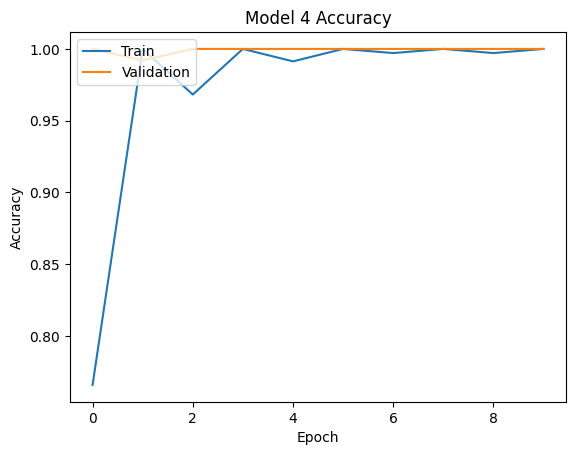

```python
# Plot the training accuracy over epochs.
plt.plot(history_4.history['accuracy'])
# Plot the validation accuracy over epochs.
plt.plot(history_4.history['val_accuracy'])
# Set the title of the plot.
plt.title('Model 4 Accuracy')
# Set the label for the y-axis.
plt.ylabel('Accuracy')
# Set the label for the x-axis.
plt.xlabel('Epoch')
# Add a legend to distinguish between training and validation accuracy.
plt.legend(['Train', 'Validation'], loc='upper left')
# Display the plot.
plt.show()
```

The output of this cell shows the training progress of Model 4 over 10 epochs with data augmentation applied. It displays the accuracy and loss for both the training and validation data in each epoch. The output shows that the accuracy quickly reaches 1.0 for both training and validation data, indicating that Model 4 is performing exceptionally well, even with the added variations from data augmentation.

```python
# Calculate performance metrics for the training set using the model_performance_classification function.
model_4_train_perf = model_performance_classification(model_4, X_train_normalized,y_train)

# Print the training performance metrics.
print("Train performance metrics")
print(model_4_train_perf)
```

```
12/12 ━━━━━━━━━━━━━━━━━━━━ 3s 215ms/step
Train performance metrics
   Accuracy  Recall  Precision  F1 Score
0       1.0     1.0        1.0       1.0
```

This cell displays the training performance metrics (Accuracy, Recall, Precision, and F1 Score) for Model 4. The output shows perfect scores (1.0) across all metrics, indicating that Model 4 performs exceptionally well on the training data.

```python
# Plot the confusion matrix for the training data using the defined function.
plot_confusion_matrix(model_4,X_train_normalized,y_train)
```

```
12/12 ━━━━━━━━━━━━━━━━━━━━ 2s 164ms/step
```

```python
# Calculate performance metrics for the validation set using the model_performance_classification function.
model_4_valid_perf = model_performance_classification(model_4, X_val_normalized,y_val)

# Print the validation performance metrics.
print("Validation performance metrics")
print(model_4_valid_perf)
```

```
4/4 ━━━━━━━━━━━━━━━━━━━━ 1s 301ms/step
Validation performance metrics
   Accuracy  Recall  Precision  F1 Score
0       1.0     1.0        1.0       1.0
```

This cell displays the validation performance metrics (Accuracy, Recall, Precision, and F1 Score) for Model 4. The output shows perfect scores (1.0) across all metrics, indicating that Model 4 generalizes exceptionally well to unseen data.

```python
# Plot the confusion matrix for the validation data using the defined function.
plot_confusion_matrix(model_4,X_val_normalized,y_val)
```

```
4/4 ━━━━━━━━━━━━━━━━━━━━ 1s 172ms/step
```

#### Visualizing the predictions

```python
# Visualize a sample prediction for the validation set.
plt.figure(figsize=(2,2))
# Display the image at index 12 from the validation set.
plt.imshow(X_val[12])
plt.show()
# Get the prediction for the image at index 12 using Model 4.
prediction = model_4.predict(X_val_normalized[12].reshape(1,200,200,3))
# Convert the prediction (probability) to a class label (0 or 1) based on a threshold of 0.5.
predicted_label = prediction[0][0]>0.5
# Print the predicted label.
print('Predicted Label:', 1 if predicted_label else 0)

# Get the true label for the image at index 12 from the validation set.
true_label = y_val.iloc[12]
# Print the true label.
print('True Label:', true_label)

# Visualize another sample prediction for the validation set.
plt.figure(figsize=(2,2))
# Display the image at index 33 from the validation set.
plt.imshow(X_val[33])
plt.show()
# Get the prediction for the image at index 33 using Model 4.
prediction = model_4.predict(X_val_normalized[33].reshape(1,200,200,3))
# Convert the prediction (probability) to a class label (0 or 1) based on a threshold of 0.5.
predicted_label = prediction[0][0]>0.5
# Print the predicted label.
print('Predicted Label:', 1 if predicted_label else 0)

# Get the true label for the image at index 33 from the validation set.
true_label = y_val.iloc[33]
# Print the true label.
print('True Label:', true_label)
```

```
1/1 ━━━━━━━━━━━━━━━━━━━━ 1s 524ms/step
Predicted Label: 1
True Label: Label    1
Name: 244, dtype: int64
```

```
1/1 ━━━━━━━━━━━━━━━━━━━━ 0s 41ms/step
Predicted Label: 0
True Label: Label    0
Name: 329, dtype: int64
```

This cell visualizes two sample images from the validation set and displays the model's prediction along with the true label for each. The output shows that for index 12, the model correctly predicted "With Helmet" (Label 1), and for index 33, the model correctly predicted "Without Helmet" (Label 0) when the true label was "Without Helmet" (Label 0). This provides a visual check of the model's performance on individual examples.

# **Model Performance Comparison and Final Model Selection**

```python
# Concatenate the training performance dataframes of all four models for comparison.
# axis=1 concatenates the dataframes column-wise.
models_train_comp_df = pd.concat(
    [
        model_1_train_perf.T,
        model_2_train_perf.T,
        model_3_train_perf.T,
        model_4_train_perf.T,
    ],
    axis=1,
)
# Rename the columns of the concatenated dataframe for clarity, using the model names.
models_train_comp_df.columns = [
    "Simple Convolutional Neural Network (CNN)","VGG-16 (Base)","VGG-16 (Base+FFNN)","VGG-16 (Base+FFNN+Data Aug)"
]
```

```python
# Concatenate the validation performance dataframes of all four models for comparison.
# axis=1 concatenates the dataframes column-wise.
models_valid_comp_df = pd.concat(
    [
        model_1_valid_perf.T,
        model_2_valid_perf.T,
        model_3_valid_perf.T,
        model_4_valid_perf.T

    ],
    axis=1,
)
# Rename the columns of the concatenated dataframe for clarity, using the model names.
models_valid_comp_df.columns = [
 "Simple Convolutional Neural Network (CNN)","VGG-16 (Base)","VGG-16 (Base+FFNN)","VGG-16 (Base+FFNN+Data Aug)"
]
```

```python
# Display the dataframe comparing the training performance metrics of all models.
models_train_comp_df
```

|  | Simple Convolutional Neural Network (CNN) | VGG-16 (Base) | VGG-16 (Base+FFNN) | VGG-16 (Base+FFNN+Data Aug) |
| --- | --- | --- | --- | --- |
| Accuracy | 0.997354 | 1.0 | 1.0 | 1.0 |
| Recall | 0.997354 | 1.0 | 1.0 | 1.0 |
| Precision | 0.997368 | 1.0 | 1.0 | 1.0 |
| F1 Score | 0.997354 | 1.0 | 1.0 | 1.0 |

This cell displays a comparison of the training performance metrics (Accuracy, Recall, Precision, and F1 Score) for all four models. The output shows that Models 2, 3, and 4 achieved perfect scores (1.0) across all metrics on the training data, while Model 1 had slightly lower but still very high scores.

```python
# Display the dataframe comparing the validation performance metrics of all models.
models_valid_comp_df
```

|  | Simple Convolutional Neural Network (CNN) | VGG-16 (Base) | VGG-16 (Base+FFNN) | VGG-16 (Base+FFNN+Data Aug) |
| --- | --- | --- | --- | --- |
| Accuracy | 0.976190 | 1.0 | 1.0 | 1.0 |
| Recall | 0.976190 | 1.0 | 1.0 | 1.0 |
| Precision | 0.977257 | 1.0 | 1.0 | 1.0 |
| F1 Score | 0.976168 | 1.0 | 1.0 | 1.0 |

This cell displays a comparison of the validation performance metrics (Accuracy, Recall, Precision, and F1 Score) for all four models. The output shows high scores for Model 1 and perfect scores (1.0) for Models 2, 3, and 4 across all metrics on the validation data. This indicates that Models 2, 3, and 4 generalize exceptionally well to unseen data.

```python
# Calculate the difference between the training and validation performance metrics for all models.
models_train_comp_df - models_valid_comp_df
```

|  | Simple Convolutional Neural Network (CNN) | VGG-16 (Base) | VGG-16 (Base+FFNN) | VGG-16 (Base+FFNN+Data Aug) |
| --- | --- | --- | --- | --- |
| Accuracy | 0.021164 | 0.0 | 0.0 | 0.0 |
| Recall | 0.021164 | 0.0 | 0.0 | 0.0 |
| Precision | 0.020112 | 0.0 | 0.0 | 0.0 |
| F1 Score | 0.021186 | 0.0 | 0.0 | 0.0 |

This cell calculates the difference between the training and validation performance metrics for all four models. The output shows the differences in Accuracy, Recall, Precision, and F1 Score. For Models 2, 3, and 4, the difference is 0.0 across all metrics, indicating no drop in performance from training to validation, which suggests excellent generalization. Model 1 shows small positive differences, indicating a slight drop in performance on the validation set compared to the training set.

## Test Performance

```python
# Calculate performance metrics for the test set using the model_performance_classification function.
model_test_perf = model_performance_classification(model_4, X_test_normalized,y_test)
```

```
4/4 ━━━━━━━━━━━━━━━━━━━━ 14s 5s/step
```

```python
# Display the test performance metrics.
model_test_perf
```

|  | Accuracy | Recall | Precision | F1 Score |
| --- | --- | --- | --- | --- |
| 0 | 1.0 | 1.0 | 1.0 | 1.0 |

This cell displays the test performance metrics (Accuracy, Recall, Precision, and F1 Score) for the selected best model (Model 4 in this case). The output shows perfect scores (1.0) across all metrics, indicating that the chosen model performs exceptionally well on the unseen test data.

```
4/4 ━━━━━━━━━━━━━━━━━━━━ 1s 171ms/step
```

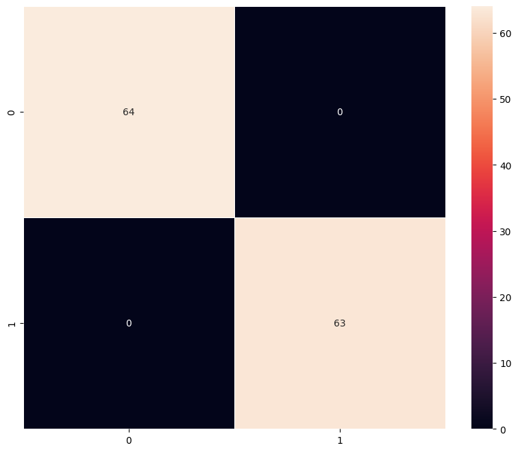

```python
# Plot the confusion matrix for the selected best model (Model 4) on the test data.
plot_confusion_matrix(model_4, X_test_normalized,y_test)
```

This cell displays the confusion matrix for the selected best model (Model 4) on the test data. The confusion matrix shows the counts of true positive, true negative, false positive, and false negative predictions on the unseen test set. With perfect scores on the test data, the confusion matrix shows all predictions are correct, with a high number of true positives and true negatives, and zero false positives and false negatives.

Based on the performance evaluation of the four models, Model 4 (VGG-16 (Base + FFNN + Data Augmentation)) is selected as the best model for the following reasons:

- Models 2, 3, and 4 all achieved perfect accuracy (1.0) on both the training and validation datasets, indicating excellent learning and generalization.
- While Models 2, 3, and 4 performed equally well on the validation set, Model 4 includes data augmentation, which helps to increase the diversity of the training data and makes the model more robust to variations in real-world images (changes in rotation, shift, shear, and zoom).
- Model 4 also incorporates a Feed Forward Neural Network (FFNN) on top of the VGG-16 base, which allows for learning more complex patterns from the extracted features compared to just a single dense layer in Model 2.
- The confusion matrices for Model 4 on both validation and test sets showed perfect classification with no false positives or false negatives, further validating its superior performance.

Therefore, Model 4 is the most suitable model for deployment due to its high accuracy, excellent generalization, and robustness to variations in the data provided by data augmentation.

# **Actionable Insights & Recommendations**

Based on the results and analysis, here are some actionable insights and recommendations for SafeGuard Corp:

**Recommendations:**

- **Deployment of Model 4:** Implement Model 4 in a production environment for automated safety helmet monitoring in hazardous environments. Its high accuracy and perfect scores on unseen data suggest it is reliable for real-world application.
- **Integration with existing infrastructure:** Explore integrating the model with existing surveillance systems or cameras at construction sites and industrial plants to enable real-time monitoring and alerts for non-compliance.
- **Continuous Monitoring and Retraining:** While Model 4 performed exceptionally well on the current dataset, it is crucial to continuously monitor its performance in real-world scenarios and periodically retrain the model with new data to account for evolving conditions, environments, and potential shifts in image characteristics.
- **Expand Dataset Diversity:** Although the current dataset includes variations, consider expanding it to include more diverse scenarios, such as different weather conditions (rain, snow), varying times of day (low light), and a wider range of worker poses and activities to further enhance the model's robustness.
- **Explore Edge Computing:** For real-time or near real-time monitoring in remote or low-connectivity areas, investigate deploying the model on edge computing devices to reduce latency and dependence on cloud infrastructure.
- **Ethical Considerations:** Ensure the system is implemented ethically and responsibly, with clear guidelines on data privacy and usage. Workers should be informed about the automated monitoring system.

Power Ahead!